Integrationen i Dalarna

# Integrationen i Dalarna

Rapporten är skapad av Samhällsanalys, Region Dalarna  
Senast uppdaterad: 2025-09-16

# Sammanfattning

- Dalarnas inrikes födda befolkning har under de senaste decennierna minskat i antal och fått en förändrad åldersstruktur. Färre i arbetsför ålder ska försörja fler, framförallt äldre, som inte arbetar. De senaste decenniernas invandring har därför haft en tydlig positiv effekt genom att både bromsa den negativa befolkningsutvecklingen och bidra till en föryngring av befolkningen och därmed arbetskraftsförsörjning.
- Arbetslösheten bland utrikes födda har historiskt varit högre än bland inrikes födda, men utvecklingen under senare år för utrikes födda visar på en markant positiv utveckling och har nästan halverats sedan år 2020. Med den ökade sysselsättningen ses en positiv utveckling också i form av förbättrad ekonomi, minskad trångboddhet och färre i behov av ekonomiskt stöd bland utrikes födda. Däremot har genomströmningstiden för godkänt i SFI ökat det senaste decenniet, vilket behöver adresseras då språkkunskaperna är viktiga för utbildning och etablering på arbetsmarknaden.
- Faktorer som minskar skillnaderna på arbetsmarknaden mellan utrikes födda och inrikes födda är framförallt höjda utbildningsnivåer och längre vistelsetid i Sverige. Däremot finns det kvarstående skillnader i form av exempelvis lägre medianinkomster, en högre andel trångbodda, en högre andel arbetslösa och även långtidsarbetslösa.
- Sammantaget ses en mycket positiv utveckling i Dalarna, men de kvarstående skillnaderna visar på vikten av ett fortsatt integrationsarbete med fokus på språk, utbildning och arbete för att minska skillnader mellan inrikes och utrikes födda.

# Inledning

I år är det 10 år sedan året då Sverige registrerade det högsta antalet asylsökande genom tiderna. 2015 sökte närmare 163 000 personer asyl i Sverige och för Dalarnas del blev 2016 det år då invandringen var som störst efter att de asylsökande fått uppehållstillstånd och folkbokförts i länet.

I november 2015 uttryckte regeringen att trycket var stort på det svenska samhället och att Sverige behövde “ett andrum för svenskt flyktingmottagande”. I och med det skärptes migrationspolitiken. Regeringen var trots det tydlig med att det stora mottagandet skulle “vara en stolthet för oss när historien skrivs” [(Sveriges Radio, 2015)](https://www.sverigesradio.se/artikel/6310364)[^1]. [Riksrevisionen (2017)](https://www.riksdagen.se/sv/dokument-och-lagar/dokument/riksrevisionens-granskningsrapport/lardomar-av-flyktingsituationen-hosten-2015-_h5b54/)[^2] granskade de centrala offentliga aktörernas beredskap och bedömde att beredskapen brast i vissa avseenden, men att kärnuppdraget ändå i huvudsak kunnat genomföras.

År 2019 publicerade Region Dalarna rapporten [Nulägesbeskrivning av integrationen i Dalarna, ett regionalt perspektiv](https://www.regiondalarna.se/contentassets/d845727dbc9f49c3b7b09a2c60456497/integrationsanalys.pdf)[^3]. Rapporten skrevs med syfte att följa upp hur den höga asylinvandringen till Sverige och Dalarna påverkat länet. År 2016 registrerades cirka 30 000 asylsökande och fram till pandemin registrerades mellan 20-30 000 årligen. År 2024 hade asylinvandringen minskat till cirka 10 000, en nivå som är den lägsta sedan 1996, och en del i det paradigmskifte som nuvarande regering verkar för, med ambitioner att öka arbetskraftsinvandringen och minska asylinvandringen [(Regeringen, 2025)](https://www.regeringen.se/pressmeddelanden/2025/01/pressbriefing-om-migrationen-till-sverige-under-2024/)[^4].

Integration kan ses som *en process där individer eller grupper med olika bakgrunder och förutsättningar blir en del av ett större socialt, ekonomiskt eller kulturellt sammanhang, samtidigt som deras egen identitet och särart respekteras*.

**Fördjupning - Integrationsbegreppet**

Beroende på sammanhang kan integration ha olika betydelser:

- **Samhällelig integration**: När människor med olika bakgrunder deltar i och bidrar till samhället på lika villkor, exempelvis genom arbete, utbildning och social interaktion.
- **Ekonomisk integration**: Att individer eller grupper har tillgång till arbetsmarknaden och ekonomiska resurser, vilket minskar ekonomiska klyftor.
- **Kulturell integration**: När olika kulturer möts och påverkar varandra utan att någon tvingas ge upp sin identitet.

[Amnå och Stigendal (2021)](https://mau.diva-portal.org/smash/get/diva2:1599404/FULLTEXT01.pdf)[^5] betonar vikten av att vara tydlig vid användningen av begrepp kopplade till integration och hänvisar till Nationalencyklopedins definition - *integration är en process som leder till att skilda enheter förenas, men det kan även gälla resultatet av en sådan process* - och sociologins användning av begreppen strukturell och kulturell integration.

Strukturell integration handlar om skyldigheter och rättigheter via samhälleliga system, lagar och regler. Kulturell integration handlar istället om människors upplevelse av samhörighet genom normer, värderingar och identiteter. En känsla av delaktighet skapar kulturell integration medan en lag skapar strukturell integration. I grunden handlar det här om integreringen av alla individer som lever i ett land, även om den vardagliga diskussionen i mångt och mycket handlar om invandrade i förhållande till de som är födda och uppväxta i ett land.

Även om integrationsbegreppet är brett, präglas samhällsdebatten av hur utrikes födda ska integreras i det svenska samhället. Det gör att det är viktigt att belysa utrikes föddas förutsättningar och utveckling i jämförelse med inrikes födda på ett antal samhällsområden så som utbildning, arbetsmarknad och boende, områden som är avgörande för exempelvis kompetens- och arbetskraftsförsörjningen på kort och lång sikt.

Den här rapportens syfte är att redovisa aktuell statistik som kan bidra till förståelsen för utrikes föddas integration i samhället i Dalarna och visa på utvecklingen över tid. Som utgångspunkt finns 2019 års rapport, med anpassningar till dagens situation och kunskapsläge. Rapporten kommer inte att behandla frågor som rör invandringens påverkan på de offentliga finanserna eller utrikes föddas inblandning i brottslighet. För den som är intresserad av att läsa mer om dessa områden rekommenderas rapporter från [Konjunkturinstitutet](https://www.konj.se/media/kpgnt5iw/specialstudie-117-invandrades-nettobidrag-till-de-offentliga-finanserna-1983-2022.pdf) och [Brottsförebyggande rådet](https://bra.se/rapporter/arkiv/2021-08-25-misstankta-for-brott-bland-personer-med-inrikes-respektive-utrikes-bakgrund).

I Region Dalarnas rapport från 2019 konstaterades bland annat att den största skiljelinjen fanns mellan hur väl integrationsprocessen fungerar för gruppen utrikes födda å ena sidan, och inrikes födda å andra sidan oavsett om de inrikes födda har utrikes eller inrikes födda föräldrar. Skillnaden i förutsättningar och förmåga mellan de inrikes födda, oavsett föräldrarnas bakgrund, var relativt liten när det gäller skolresultat och sysselsättningsgrad. Denna rapport belyser därför primärt utrikes födda i jämförelse med inrikes födda. En uppdelning sker även för kvinnor och män, utbildningsnivåer samt vistelsetid i landet i de delar det är relevant. I vissa diagram används även begreppet *Född i Sverige*, vilket ska likställas med inrikes född.

# 1 Befolkningsutveckling och invandring

Sverige är sedan en längre tid inne i en demografisk fas där de stora babyboom-kullarna från slutet av 1940- och början av 1950-talet uppnåt pensionsålder och nästa generation från 1960-talet börjar närma sig pension. Många svenska kommuner har en alltmer ålderstigen befolkning, en effekt av den urbaniseringsvåg som pågått sedan tidigt 1900-tal, då många unga lämnat landsbygden och mindre tätorter till förmån för residens- och universitetsstäder. Förutom att befolkningsutvecklingen medför färre skattebetalare som ska försörja allt fler äldre så innebär den också ett stort arbetskraftsproblem.

En stor andel äldre i befolkningen medför ekonomiska påfrestningar för en kommun då allt färre i arbetsför ålder ska försörja dem som inte förvärvsarbetar, det vill säga äldre och barn. Redan i [Långtidsutredningen (2015)](https://www.regeringen.se/contentassets/86d73b72a97345feb2a8cbc8b6700fa7/sou-2015104-langtidsutredningen-2015-huvudbetankande/)[^6] gjordes beräkningar på hur mycket kommunalskatten skulle behöva höjas i kommunerna för att upprätthålla samma servicenivå år 2040 som då, som en följd av den förändrade demografiska strukturen. Beräkningarna visade på cirka 50-procentiga ökningar, i mångas ögon orimliga skattehöjningar, vilket kan ses som en signal på hur allvarlig situationen var redan för tio år sedan.

I [Långtidsutredningen (2019)](https://www.regeringen.se/contentassets/ec035a7de89549eaacc14d82f54b4396/sou-2019_65_webb.pdf)[^7] beräknas statsbidragen till kommunsektorn, vid oförändrade kommunalskatter, behöva nästan fördubblas fram till 2035 för att möta den demografiskt betingade efterfrågan på kommunala tjänster. Utmaningen ligger dock inte främst i finansieringen, utan i att hitta arbetskraften. Störst brist på personal förväntas uppstå i landsbygdsregioner, vilket riskerar att leda till ökad ojämlikhet i levnadsförhållanden och utvecklingsmöjligheter.

Andelen utrikes födda som är i arbetsför ålder (20-64 år) i Dalarna har ökat successivt över de senaste 20 åren, från 7,2 procent år 2000 till 17,4 procent år 2024. Ökningen var särskilt tydlig under några år på mitten av 2010-talet i samband med den stora flyktingströmmen och invandringen till Sverige och Dalarna. Utrikes födda har blivit en förutsättning för att kunna arbetskraftsförsörja arbetsmarknaden i Dalarna.

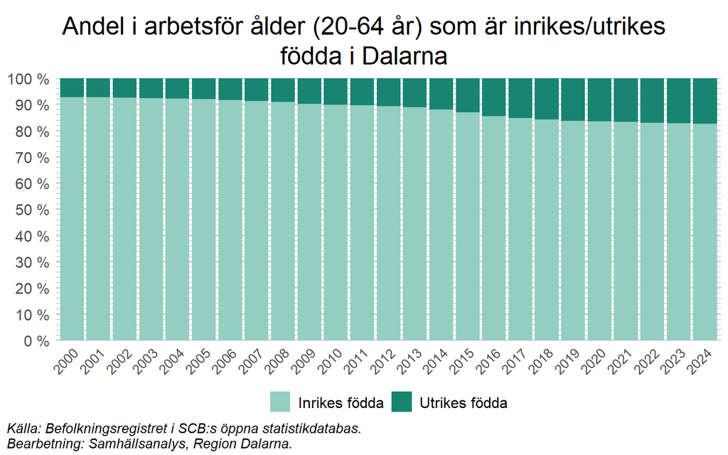

För att få en förståelse för den utrikes födda befolkningen i Dalarna och hur invandringen sett ut över tid, behöver situationen i riket som helhet analyseras. Arbetskraftsinvandringen, främst från Norden, tog fart efter andra världskriget och pågick fram till 1960-talets slut. I mitten av 1980-talet förändrades invandringens karaktär och fler flyktingar togs emot till följd av globala katastrofer. Från 1990-talet och framåt har krigssituationer i olika delar av världen föranlett en högre grad av flyktinginvandring med kriget i Syrien i mitten av 2010-talet som den tid då asylinvandringen nådde över 160 000 personer i Sverige. Därefter har antalet asylsökande minskat successivt och 2024 sökte 9 645 personer asyl i Sverige, vilket är det lägsta antalet sedan 1996. En ökning av antalet asylansökningar noteras under 2022 i samband med Rysslands anfallskrig mot Ukraina, men 2024 är antalet asylsökande det lägsta på nästan 30 år.

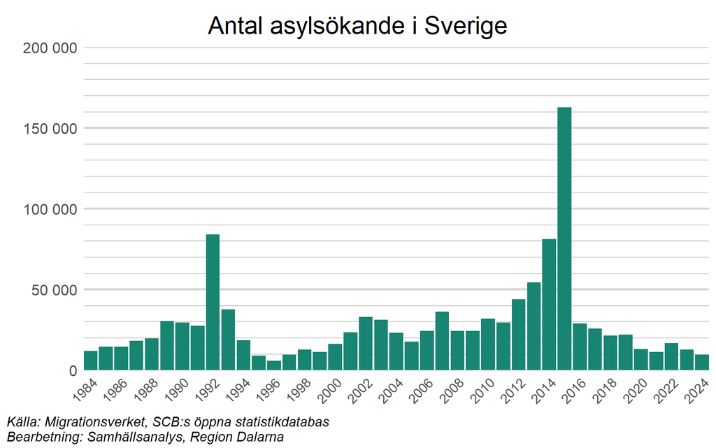

För en fördjupad beskrivning av den utrikes födda befolkningens utveckling i Sverige och Dalarna, se fördjupningsavsnittet *Historisk överblick av invandringen i Dalarna*.

**Fördjupning - Historisk överblick av invandringen i Dalarna**

Den första större invandring som påverkat Dalarna i modern tid var den arbetskraftsinvandring som skedde efter andra världskriget. Denna epok varade i stort sett under två decennier, d.v.s. under 1950- och 1960-talet.

Den svenska ekonomin expanderade snabbt efter kriget, vilket gjorde att efterfrågan på arbetskraft var större än tillgången i landet. Bristen berodde även på att ålderskullarna födda på 1920- och 30-talet var relativt små. Arbetskraftsinvandrarna kom främst från Norden, men även från övriga Europa. En överenskommelse om en gemensam nordisk arbetsmarknad år 1954 innebar att framför allt många finländare invandrade under 1960- och 70-talet, då det även var lågkonjunktur i Finland. I Dalarnas län bosatte sig dessa främst i kommuner där det fanns stor tillverkningsindustri så som i Gagnef, Borlänge, Avesta och Ludvika. En mycket liten andel av invandringen under denna tid kom från andra världsdelar. Efter andra världskriget och fram till 1970-talet låg arbetskraftsinvandringen i hela Sverige på en förhållandevis hög nivå, men i mitten av 1970-talet upphörde i princip all arbetskraftsinvandring för en tid.

I mitten av 1980-talet växte en ny typ av immigration fram. Tidigare hade de invandrare som sökt sig till Sverige av flyktingskäl främst gjort det under enstaka katastrofer. Detta scenario förändrades efter år 1984. I takt med den växande globaliseringen ökade de politiska kraven på att den rika världen borde ta sitt ansvar och acceptera flyktingar från Asien, Afrika och Mellanöstern. Sverige var ett av de länder som till en början framträdde med en jämförelsevis generös flyktingpolitik. År 1987–90 togs omkring 20 000 flyktingar emot årligen i Sverige. Detta gjorde att antalet invandrade/immigranter i Dalarna ökade under tidsperioden.

När Jugoslavien drabbades av flera inbördeskrig under första hälften av 1990-talet ökade antalet immigranter till Sverige väsentligt. I utsatta krigszoner, inte minst från Bosnien-Hercegovina, flydde långt över 100 000 människor till Sverige. Under andra hälften av 1990-talet minskade invandringen men har sedan dess varit högre. Under 2000-talet har invandringen ökat över tid, till stor del på grund av de människor som flyr från krig och förtryck i bland annat Irak, Afghanistan, Somalia och Syrien. Idag är flyktinginvandringen ett strukturellt fenomen som inte förväntas upphöra så länge det finns förtryck och krig i världen. Att invandringen har ökat beror även på ett ökat antal arbetskraftsinvandrare från nya EU-stater och fler utländska studenter.

Efter att kriget bröt ut i Syrien 2011, ökade invandringen kraftigt och nya toppnoteringar av antalet asylsökande gjordes varje år. Under 2015 var antalet asylsökande som högst, då 162 877 personer sökte asyl i Sverige. Detta var mer än dubbelt så många som under 2014 och nästan en fördubbling av den tidigare högsta noteringen från 1992 då det var krig i forna Jugoslavien.

Under den stora ökning av antalet asylsökande som skedde hösten 2015 hamnade migrations- och integrationsfrågorna högt upp på den politiska dagordningen och Sverige införde därefter en mer restriktiv immigrationspolitik. I Dalarnas län slog invandringen rekord år 2016 med 4 725 personer som immigrerade under året. Därefter har antalet immigranter i länet minskat och år 2024 bodde 2 028 personer i Dalarna som hade invandrat samma år.

Enligt internationell rätt har flyktingar rätt till skydd, så kallad asyl. Asylsökande är den som har ansökt om att få sitt skyddsbehov undersökt i ett land och därigenom få sin rätt till asyl prövad. En utländsk medborgare som erhållit uppehållstillstånd på grund av asyl, har fått det eftersom personen anses vara en flykting enligt utlänningslagen.

Efter år 2015 har antalet ansökningar om asyl i Sverige minskat. Anledningarna till detta är flera. Flyktingavtalet mellan Turkiet och EU har gjort att möjligheterna för asylsökande att ta sig över gränserna i Europa har försvårats. På svensk nivå har lagstiftningen förändrats genom att tidsbegränsade uppehållstillstånd i regel delas ut istället för permanenta, samt att familjeåterförening har försvårats. De gränskontroller som infördes i södra Sverige i början av 2016 gör att personer som saknar giltig legitimation inte längre har möjlighet att ta sig in i landet. De nya ID-kontrollerna kombinerat med andra åtgärder i Sverige och Europa har haft en stor påverkan på antalet asylsökande. Under 2024 sökte 9 645 personer asyl i Sverige, vilket är det lägsta antalet sedan 1996.

Ett stort antal asylsökande ett år leder ofta till att invandringen ökar året därpå. Det beror på att asylsökande räknas som invandrade först när de har fått uppehållstillstånd och folkbokförts i Sverige. Detta gör att antalet immigranter i hög grad påverkas av hur många beslut om uppehållstillstånd som Migrationsverket fastställer, samt hur stor andel av dessa ärenden som blir beviljade. Rekordnivån för antalet asylsökande år 2015, ledde till att invandringen slog rekord i Sverige år 2016. Även antalet invandrade enligt statistiken åren 2017 och 2018 kan i stor grad härledas till det stora antalet asylsökande år 2015. Det handlar både om att många fick vänta länge på beslut om huruvida de fick stanna i landet, och för att anhöriginvandringen sedan har ökat till dem som fick uppehållstillstånd.

Den totala befolkningen i Dalarna varierar en del över tid och var som störst 1994 med 291 203 invånare, men minskade därefter till 275 618 år 2007. Vid utgången av 2024 noterades 286 546 invånare i länet, vilket är en minskning från de senaste årens högsta nivå, 288 387 år 2021.

Mellan 2000 och 2024 ökade antalet utrikes födda personer i Dalarnas län från 17 031 till 37 414 personer. Effekten av den ökade invandringen under 2000-talet är därmed att den utrikes födda befolkningen i Dalarna har mer än fördubblats. Ökningen skedde fram till 2019, men därefter har den utrikes födda befolkningen i Dalarna minskat något. Antalet inrikes födda minskade under samma tid från 261 228 personer till 249 132 personer. Genom att studera befolkningsutvecklingen för inrikes och utrikes födda i länet de senaste åren, blir det tydligt att befolkningen i länet som helhet hade minskat utan invandringen.

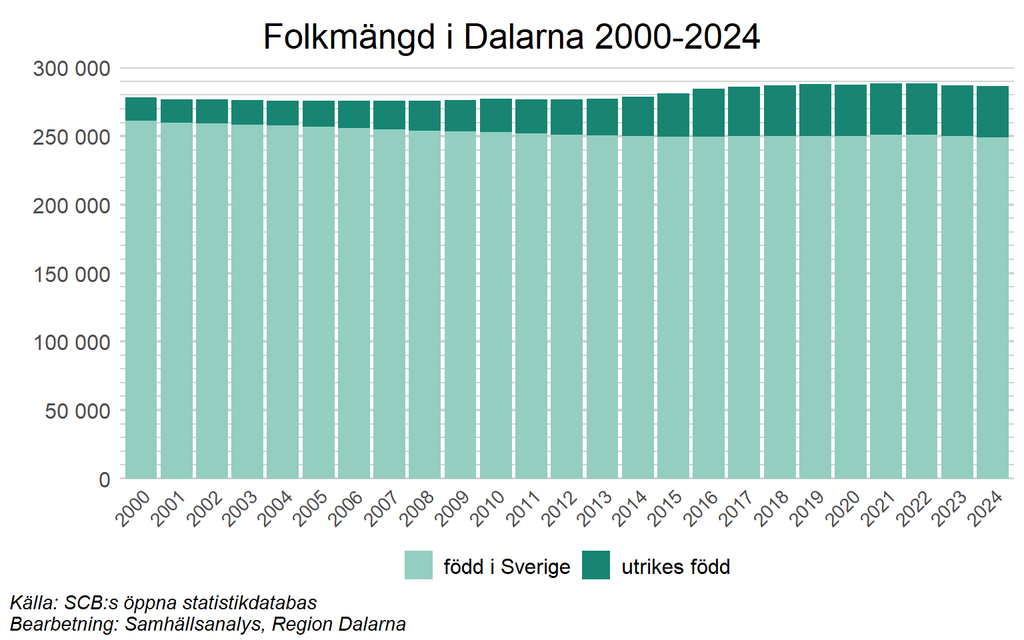

På kommunnivå ökade befolkningen totalt sett i åtta av länets kommuner mellan år 2000–2024, medan den minskade i sju av dem (se det vänstra diagrammet nedan). Antalet utrikes födda personer har under tidsperioden ökat i Dalarnas läns samtliga kommuner, medan antalet inrikes födda personer har minskat i alla kommuner förutom Falun och Gagnef. Slutsatsen blir att de kommuner i länet som har växt i invånarantal, med undantagen Falun och Gagnef, har gjort det som en följd av invandring, medan de kommuner som krympt har begränsat befolkningsminskningen genom att fler har invandrat än utvandrat. Noteras bör även att utrikes föddas barn ingår i kategorin inrikes födda. Ökningen av antalet utrikes födda var i relation till befolkningsmängd störst i Hedemora, Avesta, Ludvika och Borlänge.

I det högra diagrammet nedan syns att andelen av befolkningen som är utrikes födda är lägre i samtliga Dalarnas kommuner jämfört med riket, där ungefär 21 procent av invånarna är födda i ett annat land än Sverige år 2024. Högst andel utrikes födda i Dalarna återfinns i Ludvika där ungefär 20 procent av befolkningen är utrikes födda. Även Borlänge och Avesta har en relativt stor andel utrikes födda (18 respektive 17 procent). Lägst andel utrikes födda finns i Gagnef, där endast 7 procent av befolkningen är utrikes födda.

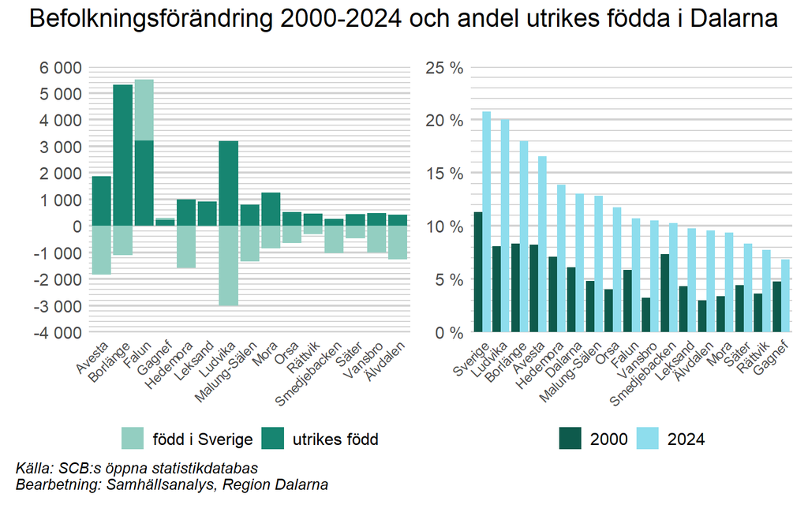

Andelen utrikes födda har ökat i samtliga av Dalarnas kommuner mellan 2000 och 2024, vilket kommer av att invandringen varit större än utvandringen under hela 2000-talet, samtidigt som antalet inrikes födda minskat i de flesta kommuner. Hur stor ökningen varit skiljer dock tydligt mellan kommunerna. I Ludvika har andelen utrikes födda exempelvis ökat med 12 procentenheter sedan 2000, medan ökningen har varit klart lägre i näraliggande Smedjebacken (ungefär 3 procentenheter under samma tidsperiod) eller Gagnef (ungefär 2 procentenheter).

För att förstå befolkningsutvecklingen i Dalarna är det även viktigt att undersöka de beteendemönster som, vid sidan om invandringen, påverkar befolkningsutvecklingen; födelseöverskottet och den inrikes flyttningen.

Mellan år 2000 och 2024 har antalet döda i Dalarna varit fler än antalet födda och antalet utflyttade till övriga Sverige har varit fler än antalet inflyttade från övriga Sverige. Totalt flyttade 14 490 personer netto från Dalarna till andra delar av Sverige under perioden, medan det dog 12 314 fler personer än det föddes. Under samma period var invandringsöverskottet 32 129 personer. Att Dalarnas befolkning har växt under 2000-talet beror således på att invandringen har varit relativt stor.

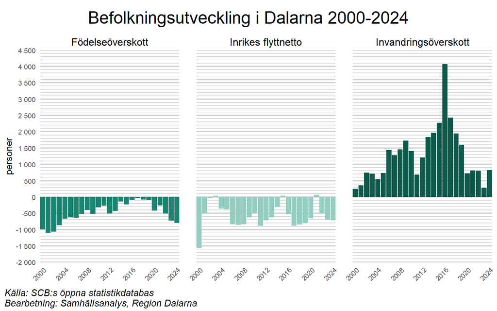

Födelseunderskottet minskade successivt från år 2000 och fram till 2019, för att därefter öka kraftigt fram till 2024. Utvecklingen till 2019 beror i stor grad på att de stora ålderskullar som föddes runt 1990 befunnit sig i barnafödande åldrar, samt en generös familje- och socialpolitik och en stor invandring. De som invandrade till Dalarna i mitten av 2010-talet var generellt sett unga och i en ålder när det är vanligt att skaffa barn. Utrikes födda kvinnor har även en hög fruktsamhet direkt efter att de invandrat till Sverige, men därefter minskar den successivt. Att fruktsamhetstalen är extra höga bland kvinnor som nyligen invandrat beror sannolikt på att många kvinnors invandring är knutet till familjebildning, och att de kommer till Sverige för att återförenas med sin familj eller för att bilda familj.

De senaste årens markanta minskning av födelsetalen är en fråga som förvånar demografer. Det är inte längre en lika tydlig koppling mellan makroekonomiska upp- och nedgångar eller välfärdssystemets utformning och födslar. Nedgången verkar mer vara knuten till oro inför framtiden och påverkar framför allt sannolikheten att skaffa sitt första barn. För en fördjupad genomgång av förändringar i födelsetal, se avsnitt 2.1 i [Befolkningsutvecklingen i Dalarna](https://samhallsanalys.regiondalarna.se/befolkningsutveckling)[^8].

Förutom att antalet immigranter var stort under framförallt mitten på 2010-talet, har ursprungsländerna förändrats över tid, med ett större antal asylsökande från utomeuropeiska länder. År 2024 kan konstateras att det skett förändringar i från vilka länder de invandrade kommer. År 2024 var Syrien det land som flest invånare i Dalarna var födda i (vid sidan om Sverige). Totalt 4 367 invånare i Dalarna hade Syrien som födelseland. Detta är en stor förändring mot 2010, då antalet invånare i Dalarna med Syrien som födelseland kan räknas i låga hundratal. Orsaken till detta är naturligtvis inbördeskriget i Syrien under 2010-talet, när många från landet flydde till Europa och Sverige. Andra länder från vilka invandringen har ökat tydligt under 2000-talet är Somalia och Eritrea.

Det land som näst flest invånare i Dalarna var födda i år 2024 var Finland med 3 747 invånare. Detta är en tydlig minskning sedan år 2000, när antalet invånare i Dalarna med Finland som födelseland var drygt 6 000. Orsaken till detta är att många invandrade från Finland under åren runt och efter andra världskriget. Dessa börjar således komma upp i åren och eftersom relativt få flyttar till Sverige från Finland idag minskar antalet personer som är födda i Finland i Dalarna stadigt.

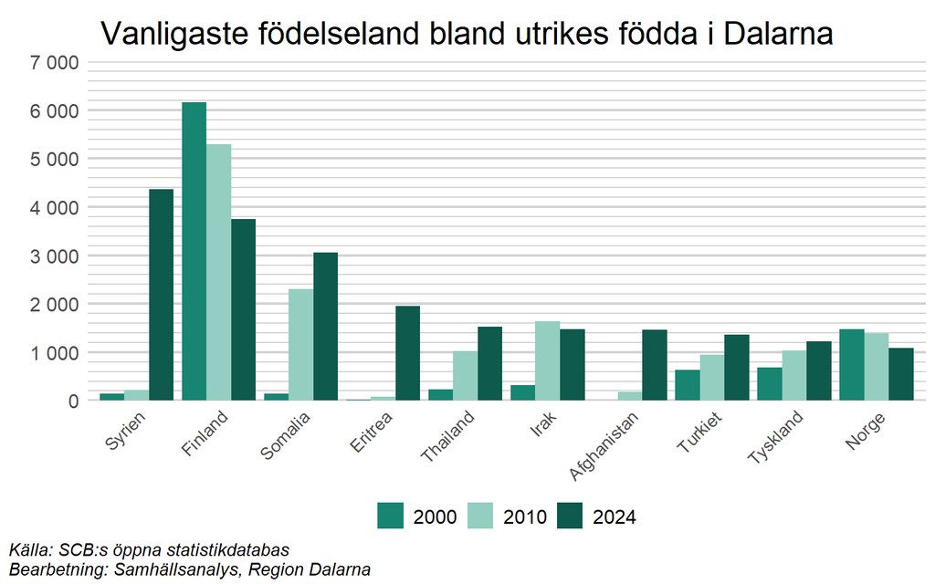

När de utrikes födda personer som är bosatta i Dalarna kartläggs utifrån deras invandringsår till Sverige, framgår att många invandrade i mitten av 2010-talet. Sedan dess har åtskilliga lämnat Dalarna, men 2016 är fortfarande det år när flest utrikes födda boende i Dalarna invandrade till Sverige. År 2024 bodde 2 028 personer i Dalarna som hade invandrat till Sverige samma år, vilket är klart fler än åren innan. Detta kan naturligtvis delvis förklaras av att vissa som invandrade under åren innan har lämnat Dalarna för andra delar av Sverige, men en viktig orsak är också att personer födda i Ukraina, som tidigare haft ett uppehållstillstånd med tillfälligt skydd enligt massflyktdirektivet, har haft möjlighet att ansöka om att bli folkbokförda i Sverige sedan i juni 2024.

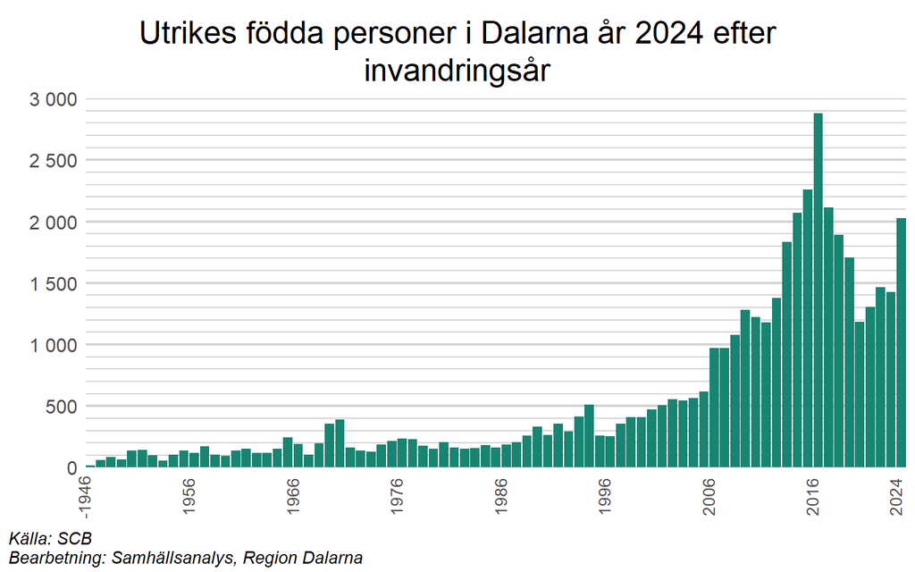

Vid en analys av åldersfördelningen bland Dalarnas befolkning uppdelat på den inrikes- och utrikes födda befolkningen blir det tydligt att den utrikes födda befolkningen i länet är väsentligt yngre än den inrikes födda, och innefattar en större andel personer i arbetsför ålder (se de svarta linjerna i diagrammet nedan). Detta beror på att personer som invandrar generellt är yngre än genomsnittet för en befolkning. Följden blir att invandringen totalt sett har gett en föryngrande effekt på befolkningen. Det finns även stora variationer i medelålder mellan olika grupper av utrikes födda beroende på invandringsår och födelseland. Utrikes födda utgör ungefär 13 procent av den totala befolkningen i Dalarnas län och är därmed betydligt färre än inrikes födda.

[figure not shown]

Befolkningen i arbetsför ålder (20-64 år) är särskilt intressant att fokusera på då den bidrar till att balansera en allt äldre befolkning och förbättrar möjligheten att säkerställa tillgång till arbetskraft för näringsliv och offentlig sektor i framtiden.

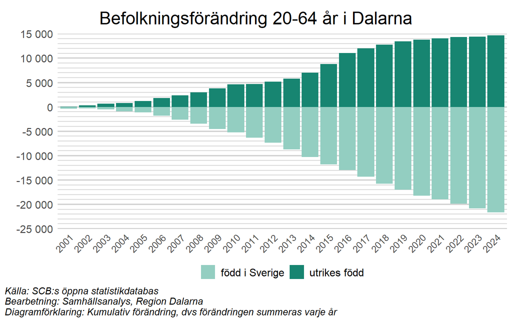

Enligt SCB:s befolkningsprognos från juni 2024 förväntas antalet utrikes födda i Dalarnas län mellan 20-64 år att öka med 702 personer mellan 2025 och 2040, medan antalet inrikes födda personer i länet förväntas att minska med 6 029 personer [(SCB Statistikdatabasen)](https://www.statistikdatabasen.scb.se/pxweb/sv/ssd/START__BE__BE0401__BE0401A/BefProgRegFakN/)[^9].

Enligt prognosen kommer antalet personer mellan 20-64 år således att minska tydligt i Dalarna fram till 2040, vilket förstärker länets utmaningar med arbetskrafts- och kompetensförsörjning. Det blir då extra viktigt att ta vara på den resurs som utrikesfödda kan utgöra, annars riskerar såväl näringsliv som offentlig sektor att få mycket svårt med arbetskraftsförsörjningen.

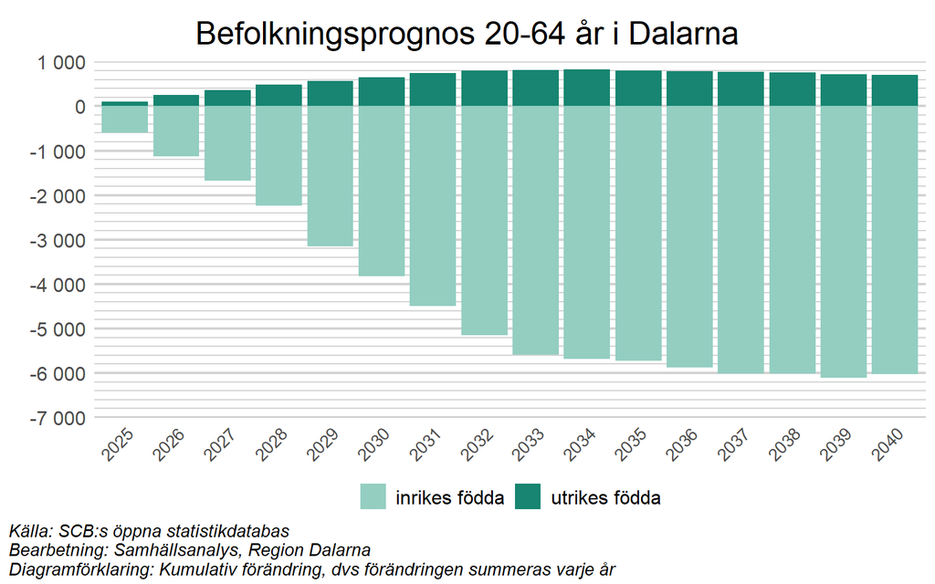

Den demografiska översikten visar således att andelen utrikes födda i Dalarna ökat över tid och bidragit till att både föryngra och vidmakthålla länets invånarantal.

# 2 Språk och utbildning

Ett viktigt steg för att kunna integreras i ett samhälle är att lära sig språket. Språkkunskaper ger förutsättningar för utbildning som i sin tur skapar möjligheter på arbetsmarknaden. I detta avsnitt görs en genomgång av utvecklingen för utrikes födda inom språk och utbildning. I nästa avsnitt diskuteras utvecklingen på arbetsmarknaden.

## 2.1 Språk

Att ha grundläggande kunskaper i det officiella språket är viktigt för att kunna delta i samhället, både socialt, ekonomiskt och kulturellt. För att underlätta integrationen av nyanlända har Sverige ett system för svenskundervisning för invandrare, hädanefter benämnt SFI. SFI är en utbildning som erbjuds till personer som är bosatta i Sverige men saknar sådana grundläggande kunskaper i svenska språket som utbildningen syftar till att ge. Från andra kalenderhalvåret det år hen fyller 16 år har personen rätt till SFI ([Skolverket](https://www.skolverket.se/regler-och-ansvar/ansvar-i-skolfragor/ratt-till-sfi)).

För de personer boende i Dalarna som blivit godkända i SFI har vistelsetiden i Sverige fram till godkända studier förändrats relativt mycket över tid och på senare tid ökat, oavsett indidivens utbildningsnivå. Under några år i slutet på 1990-talet hade de män och kvinnor med förgymnasial utbildning som blivit godkända i SFI varit i Sverige ungefär 1300-1400 dagar (medianvärde). Därefter såväl ökade som minskade vistelsetiden fram till mitten av 2010-talet, innan den ökade tydligt fram till åren runt pandemin (2020-2021). År 2023 hade de män och kvinnor med förgymnasial utbildning som blev godkända i SFI i Dalarna varit i Sverige i 1693 dagar, vilket är ungefär lika länge som de som blev godkända åren innan. För personer med längre utbildningar (gymnasial eller eftergymnasial) är trenden liknande, men vistelsetiden generellt kortare.

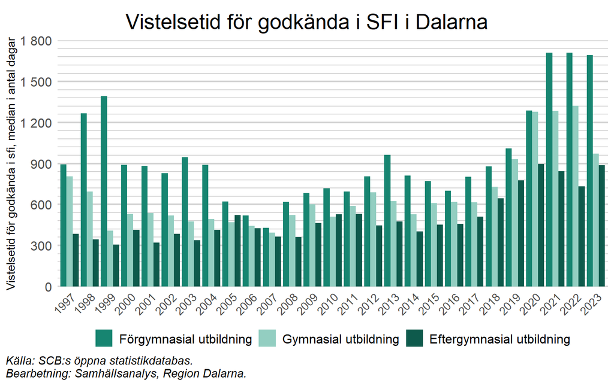

Hur lång tid det tar att slutföra SFI, från när personen invandrade till Sverige (vistelsetid), påverkas av vilken utbildningsnivå den invandrade har. Kvinnor med förgymnasial utbildning som blev godkända i SFI år 2023 hade varit i Sverige i 1954 dagar (medianvärde), att jämföra med 817 dagar för kvinnor med gymnasial utbildning. För kvinnor med högst utbildning (eftergymnasial) tog det 906 dagar, vilket alltså är något längre tid än för de med gymnasial utbildning.

Män med förgymnasial utbildning som blev godkända i SFI under år 2023 hade varit i Sverige betydligt kortare tid än kvinnorna med motsvarande utbildning, 1056 dagar (medianvärde). Till skillnad från kvinnorna hade dock de män med gymnasial utbildning som blivit godkända under år 2023 varit i Sverige längre tid än motsvarande personer med förgymnasial utbildning, hela 1437 dagar, vilket även är klart längre än kvinnorna med gymnasial utbildning som blev godkända. De män med längst utbildning (eftergymnasial) hade varit i Sverige i 823 dagar när de blev godkända i SFI år 2023, vilket är något kortare tid än kvinnorna med motsvarande utbildning.

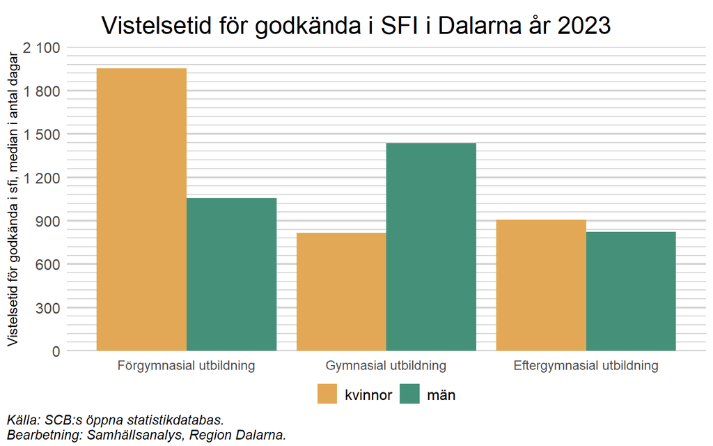

En orsak till att vistelsetiden ökade stadigt för de som blev godkända från mitten av 2010-talet, oavsett utbildningsbakgrund, kan vara att många då invandrade till Sverige. Det, i kombination med en pandemi som sannolikt försvårade möjligheterna till undervisning, kan ha gjort att det tog längre tid att slutföra SFI och har resulterat i historiskt långa vistelsetider för att nå godkänt i SFI.

Från 1 januari 2025 har kraven på att delta i SFI skärpts. Deltagande är bland annat begränsat till tre år och en individuell studieplan ska upprättas i samband med antagning. Det innebär att genomströmningstiderna behöver återgå till den nivå som rådde innan pandemin, utan att kvaliteten i utbildningen försämras. En sänkning av genomströmningstiderna ökar i sin tur möjigheten att gå vidare i utbildningssystemet och skynda på integrationsprocessen.

## 2.2 Utbildning

En fullgjord gymnasieutbildning är en av de viktigaste faktorerna för ett gott liv på många sätt, såsom hälsa, inkomst, medellivslängd och möjligheten till arbete. De med en högre utbildning lever generellt längre ([SCB](https://www.scb.se/hitta-statistik/statistik-efter-amne/befolkning-och-levnadsforhallanden/befolkningens-sammansattning-och-utveckling/demografisk-analys/pong/statistiknyhet/livslangd-efter-utbildningsniva/)), har en genomsnittligt högre inkomst ([SCB](https://www.scb.se/hitta-statistik/sverige-i-siffror/utbildning-jobb-och-pengar/medelloner-i-sverige/)) och mår i allmänhet bättre än de med lägre utbildning ([FHM](https://www.folkhalsomyndigheten.se/contentassets/ca6067606d8847f7945e922642853caf/utbildning-halsa-faktablad.pdf)). Utbildningsnivån hos utrikes födda har därför en stor påverkan på möjligheterna att etablera sig i samhället, särskilt bland de unga som anländer till Sverige under skolåren och har hela arbetslivet framför sig. Idag behövs det enligt Arbetsförmedlingen i regel gymnasiekompetens för att ha en god chans att etablera sig på arbetsmarknaden, även när det gäller bristyrken.

Att gruppen utrikes födda är en heterogen grupp blir tydligt när utbildningsnivån studeras (se diagram nedan). Den största skillnaden mellan utrikes och inrikes födda är att en större andel av de utrikes födda har en förgymnasial utbildning och en mindre andel gymnasial utbildning. Andelen personer som har eftergymnasial utbildning är ungefär densamma för inrikes och utrikes födda. En lite högre andel kvinnor födda i Sverige har eftergymnasial utbildning än utrikes födda kvinnor, men bland män är förhållandet det omvända. Arbetskraftsinvandrare har generellt sett en högre utbildningsnivå än flyktinginvandrare, och skillnaderna i utbildningsnivå är även stora mellan olika ursprungsländer.

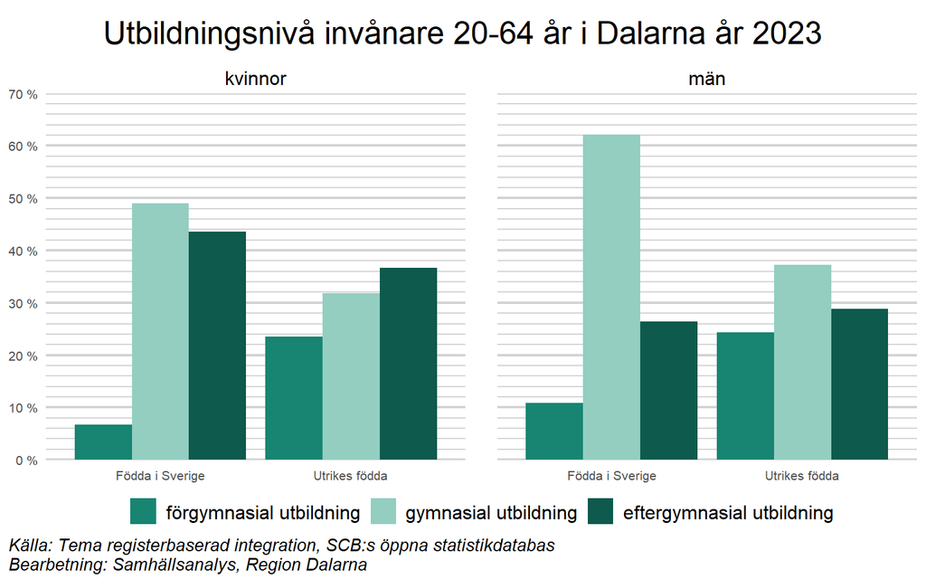

Eftersom det finns stora skillnader i utbildningsbakgrund bland utrikes födda, är det svårt att tala om dem som en samlad grupp. Personer med låg respektive hög utbildning stöter på olika typer av utmaningar på arbetsmarknaden.

En förhållandevis stor andel av de utrikes födda i Dalarna hade år 2024 en eftergymnasial utbildning om minst 3 år. Högst utbildning hade de som relativt nyligen invandrat till Sverige, vilket är en indikation på att en större andel av dessa är arbetskraftsinvandrare. Exempelvis har ungefär 30 procent av de som invandrade till Sverige mellan 2021 och 2022 (2-3 år i diagrammet nedan) och nu bor i Dalarna en eftergymnasial utbildning om minst tre år, vilket är klart fler än motsvarande andel bland inrikes födda. Bland övriga utbildningsnivåer ökar andelen med gymnasial utbildning tydligt ju längre tid som gått sedan invandringen. Störst andel med förgymnasial utbildning finns bland de som invandrat mellan 2015 och 2020 (4-9 år i diagrammet nedan).

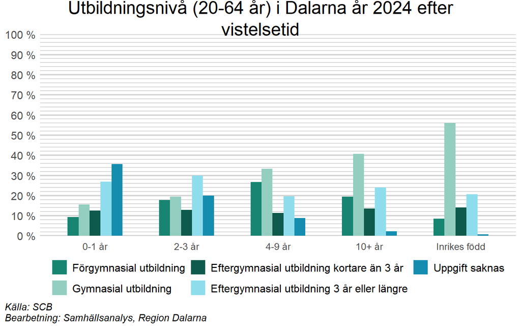

Viktigt att notera är även att det saknas uppgifter om utbildningsnivå för en stor andel av de utrikes födda, speciellt för dem som varit en kortare tid i landet.

Eftersom en gymnasieutbildning förbättrar möjligheten att etablera sig på arbetsmarknaden är en viktig aspekt att undersöka hur stor andel av avgångseleverna i årskurs 9 i länet som är behöriga till att påbörja gymnasiestudier. Ofullständiga eller låga betyg är i första hand ett problem för den enskilde, då personens valmöjligheter begränsas och etableringen på arbetsmarknaden försvåras. Att en stor andel elever inte blir behöriga till gymnasiet kan även innebära ett samhällsproblem. Samhället misslyckas med att ta tillvara på elevernas potential om de inte når målen för utbildningen i skolan. Det finns även ett starkt samband mellan dåliga skolresultat och sociala problem [(Westin Lundqvist, W. m fl, 2019)](https://www.hv.se/contentassets/82eff73069584573b03f43956b661c05/laga-skolresultat-i-socialt-utsatta-omraden_.pdf)[^10].

Skillnaden i andelen behöriga till gymnasiet hos avgångselever i årskurs 9 mellan inrikes och utrikes födda är fortsatt stor i Dalarna. Sedan 2005 har gymnasiebehörigheten för inrikes födda minskat från 91 procent till 86 procent år 2023. Skillnaden mellan inrikes födda pojkar och flickor är marginell men utvecklingen har varit svagt negativ sedan 2005.

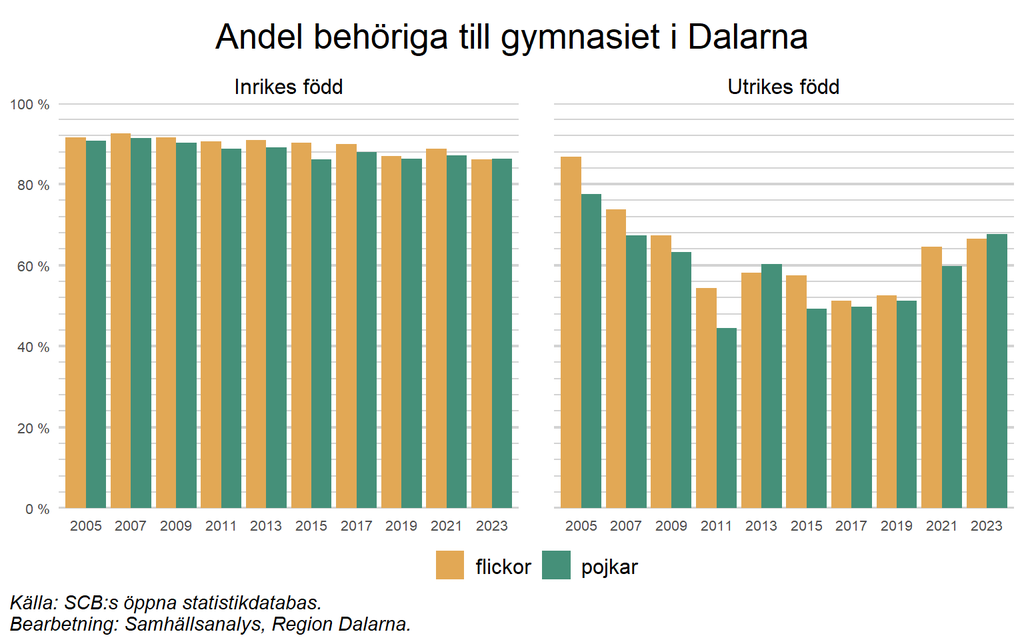

För utrikes födda, både pojkar och flickor, har det varit en stor variation under de senaste 20 åren. 2005 var behörigheten för utrikes födda flickor cirka 5 procentenheter lägre än för inrikes födda flickor. För utrikes födda pojkar var skillnaden nästan tre gånger så stor vid samma tidpunkt. Sedan dess har andelen behöriga utrikes födda flickor fallit fram till 2017, för att därefter öka till 66 procent år 2023. För utrikes födda pojkar var minskningen som störst fram till 2011 för att därefter öka från 44 procent till 68 procent år 2023. Det innebär att utrikes födda pojkar har en högre andel behöriga till gymnasiet än utrikes födda flickor år 2023, vilket är första gången sedan 2013.

Det finns stora skillnader i gymnasiebehörighet mellan grupper med olika vistelsetid i Dalarna där behörigheten är större ju längre eleverna har vistats i Sverige (se diagram nedan). Behörigheten för elever som går ut årskurs 9 med en vistelsetid som är 10 år eller längre, är i det närmaste att likställa med behörigheten för inrikes födda. I gruppen med en vistelsetid 4-9 år är behörigheten omkring 20 procentenheter lägre och i gruppen vistelsetid 2-3 år är den ytterligare 24 procentenheter lägre, vilket innebär att ungefär 40 procent i gruppen har gymnasiebehörighet.

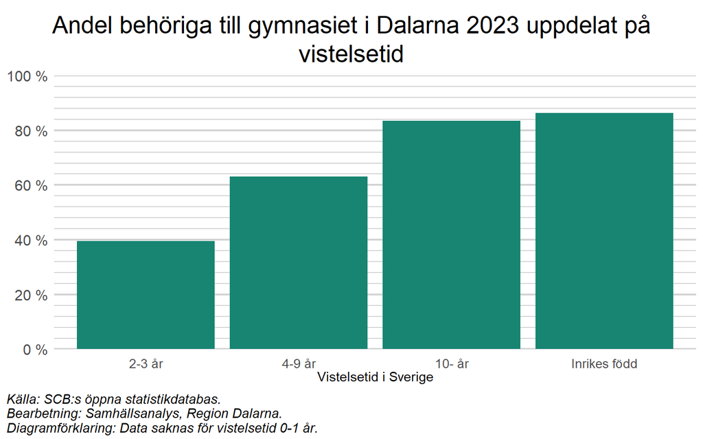

[Mörtlund (2020)](https://www.ifau.se/Forskning/Publikationer/Rapporter/2020/arbetet-med-nyanlanda-elever-i-grundskolan/)[^11] noterade stora utmaningar med att kvalitetssäkra undervisningen i grundskolan, trots insatser kring språk- och kunskapsutvecklande arbetssätt. Att på en kort tid lära sig svenska språket och samtidigt utveckla ämneskunskaper är en svår utmaning.

En annan aspekt som är viktig att mäta är hur stor andel av avgångseleverna i gymnasiet som är behöriga till att påbörja högskolestudier. En problematik att ta hänsyn till är att SCB justerat statistiken för behöriga till högskolan under 2014-2016, vilket påverkar andelarna (se statistikfotnot hos [SCB](https://www.statistikdatabasen.scb.se/pxweb/sv/ssd/START__AA__AA0003__AA0003H/IntGr8RikKON2/)). För dessa år minskar den genomsnittliga andelen behöriga med 8-9 procentenheter. Större variationer kan finnas regionalt.

Diagrammet nedan visar att utvecklingen för inrikes födda är relativt opåverkad fram till 2013, men från 2014 (syns inte i diagrammet nedan) faller andelen behöriga markant. Minskningen är som störst för män, ca 38 procentenheter mellan 2013 och 2023. År 2023 var andelen högskolebehöriga inrikes födda män ungefär 51 procent. Andelen högskolebehöriga inrikes födda kvinnor har också minskat under perioden, men inte i samma utsträckning. 2023 är cirka 74 procent behöriga.

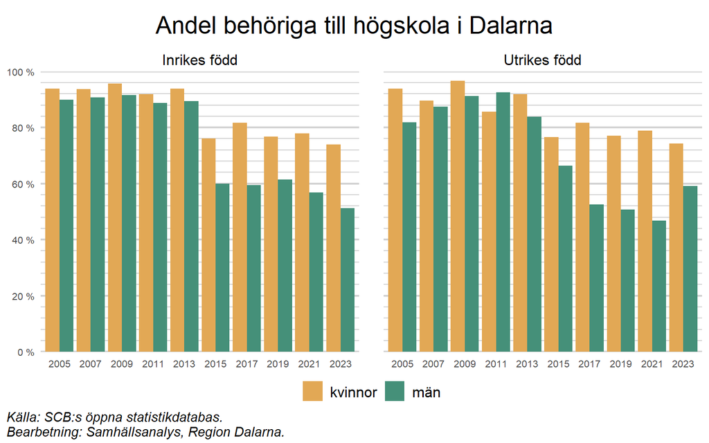

Skillnaderna mellan inrikes och utrikes födda när det gäller högskolebehörighet är inte lika stora som i fallet med gymnasiebehörighet. Fram till 2013 är skillnaden några procentenheter för både kvinnor och män, men därefter faller andelen utrikes födda män med högskolebehörighet till ungefär 47 procent år 2021. 2023 kan dock observeras en markant förbättring för männen. För kvinnor är inte nedgången alls lika påtaglig, utan liknar mer den för inrikes födda kvinnor. Sannolikt är detta en effekt av vilka som tagit en gymnasieexamen eller erhållit ett studiebevis.

# 3 Arbetsmarknad

I förlängningen av att studera är att arbeta en viktig komponent i integrationen i samhället. Utrikes födda har generellt en svagare ställning på arbetsmarknaden, vilket speglas i att sysselsättningen bland utrikes födda är lägre än bland inrikes födda personer, samt att arbetslösheten, inklusive långtidsarbetslösheten, är högre. Forskning visar att bland annat härkomst, ålder, kön, utbildningsnivå, konjunkturläge, språkkunskaper och kontaktnät är avgörande för utrikes föddas möjligheter att etablera sig på arbetsmarknaden [(IFAU, 2022)](https://www.ifau.se/Press/Forskningssammanfattningar/Utrikes-foddas-eta-pa-arbetsmarknaden-/)[^12]. Arbetslöshets- och sysselsättningsnivåerna bland utrikes födda varierar dock stort mellan olika grupper.

## 3.1 Arbetslöshet och sysselsättning

Arbetsmarknadsstatistik finns både hos SCB och Arbetsförmedlingen, men i denna rapport används statistik från SCB. För mer information om arbetsmarknadsstatistiken, klicka nedan:

**Mer information om arbetsmarknadsstatistiken**

Arbetslösheten visar hur många av de aktivt arbetssökande som inte har ett arbete. I denna rapport används främst SCB:s statistik, antingen via Arbetskraftsundersökningarna (AKU) eller Befolkningens arbetsmarknadsstatus (BAS). I fallet med långtidsarbetslöshet hämtas data från Kolada.se, med Arbetsförmedlingen som grundkälla.

SCB:s Arbetskraftsundersökningar (AKU) beskriver utvecklingen på arbetsmarknaden för Sveriges befolkning i åldern 15–74 år. AKU visar bland annat antal och andel sysselsatta respektive arbetslösa per månad, kvartal och år. Det är den enda källan med kontinuerliga uppgifter om den totala arbetslösheten och står för det officiella arbetslöshetstalet.

Enligt AKU är en person *sysselsatt* om den under mätveckan har arbetat minst en timme, eller varit tillfälligt frånvarande från ett arbete (semester, tjänstledighet, sjukdom, osv). Även personer som deltar i vissa arbetsmarknadspolitiska program räknas som sysselsatta (lönebidrag, start av näringsverksamhet osv).

Arbetslösa är personer som var utan arbete under mätveckan, men som sökt arbete under de senaste fyra veckorna (mätveckan och tre veckor bakåt) och kunde arbeta mätveckan eller börja inom 14 dagar från mätveckans slut. Arbetslösa omfattar även personer som har fått ett arbete som börjar inom tre månader, förutsatt att de skulle ha kunnat arbeta mätveckan eller börja inom 14 dagar från mätveckans slut.

AKU är en urvalsundersökning som genomförs genom intervjuer och är inte nedbrytbar på finare geografisk nivå än län och storstadsregioner. För att analysera sysselsättning på finare geografisk nivå än vad som finns i AKU kan registerstatistik i form av Befolkningens arbetsmarknadsstatus (BAS) (tidigare Registerbaserad arbetsmarknadsstatistik (RAMS)).

Syftet med BAS är att redovisa den folkbokförda befolkningen i sex arbetsmarknadsstatusar; Sysselsatta, Arbetslösa, Studerande, Pensionärer, Sjuka samt Övriga. De sysselsatta redovisas i statistiken för åldersgruppen 15–74 år och kan delas upp i anställda och egenföretagare. Sysselsatta definieras genom att man antingen fått lön som utgör underlag för arbetsgivaravgift, som redovisats i AGI eller i förenklad arbetsgivardeklaration. Alternativt att man som företagare redovisat underlag för förväntad moms. Även tillfälligt frånvarande som föräldralediga och sjukskrivna räknas med som sysselsatta, liksom folkbokförda i Sverige som arbetar i annat nordiskt land.

Vid längre jämförelser över tid används både BAS och RAMS.

Arbetsförmedlingen rapporterar också arbetslöshetsstatistik, men den skiljer sig från SCB:s p g a ett annat dataunderlag och mått. För en jämförelse mellan SCB:s och Arbetsförmedlingens statistik, se [Arbetsförmedlingen](https://arbetsformedlingen.se/statistik/sok-statistik/forklaring-av-statistiken/arbetsformedlingens-och-scbs-statistik)).

Som långtidsarbetslös räknas den som har varit öppet arbetslös eller i program med aktivitetsstöd i minst sex månader.

En viktig aspekt för integrationen är hur stark arbetsmarknaden är vid tidpunkten för invandringen. Dalarna har generellt sett haft en stark arbetsmarknad över lång tid jämfört med riket, men arbetslösheten har varierat relativt mycket. I början av 1990-talet var arbetslösheten generellt väldigt låg, strax under 2 procent, men mångdubblades på bara ett par år i samband med finans- och fastighetskrisen (hädanefter 90-talskrisen), den djupaste ekonomiska krisen i Sverige i modern tid. Samtidigt tog Sverige under 1990-talet emot ett stort antal asylsökande från Balkan. Mellan 1990 och 1994 gick sysselsättningen ned med drygt 16 procent och nära 600 000 personer blev arbetslösa.

Arbetslösheten i Dalarna ökade mer än arbetslösheten i Sverige i samband med krisen, vilket potentiellt kan bero på att Dalarna under 1990-talet var ett län med en stor tillverkningsindustri. Därefter minskade arbetslösheten tydligt under inledningen av 2000-talet innan den återigen ökade och nådde en topp i samband med den globala finanskrisen 2008. På senare år har arbetslösheten varierat en del mellan åren, men legat på en relativt jämn nivå i Dalarna. Under 2024 minskade arbetslösheten i Dalarna, men ökade i riket. I samband med flyktingtillströmningen 2015 var arbetslösheten omkring 7 procent och ökade någon procentenhet de följande åren, men inte alls i samma utsträckning som vid 90-talskrisen eller vid finanskrisen 2008.

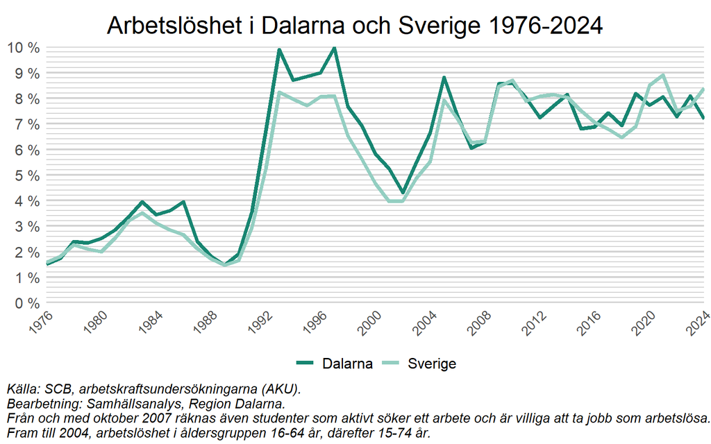

En nationell jämförelse av arbetslösheten bland utrikes respektive inrikes födda åskådliggör ett antal viktiga skillnader, men också likheter. Arbetslösheten är generellt högre för utrikes födda än för inrikes födda. Arbetslösheten för inrikes födda i Dalarna var i juni 2025 lägre än rikets, 2,1 procent bland kvinnor och 3 procent bland män (se diagrammet nedan).

Arbetslösheten bland utrikes födda är däremot betydligt högre i samtliga av Sveriges län. I Dalarna är skillnaden i arbetslöshet mellan utrikes och inrikes födda knappt 12 procentenheter för kvinnor och 8 procentenheter för män. Vidare är arbetslösheten bland gruppen utrikes födda kvinnor högre än i gruppen utrikes födda män i samtliga av Sveriges län.

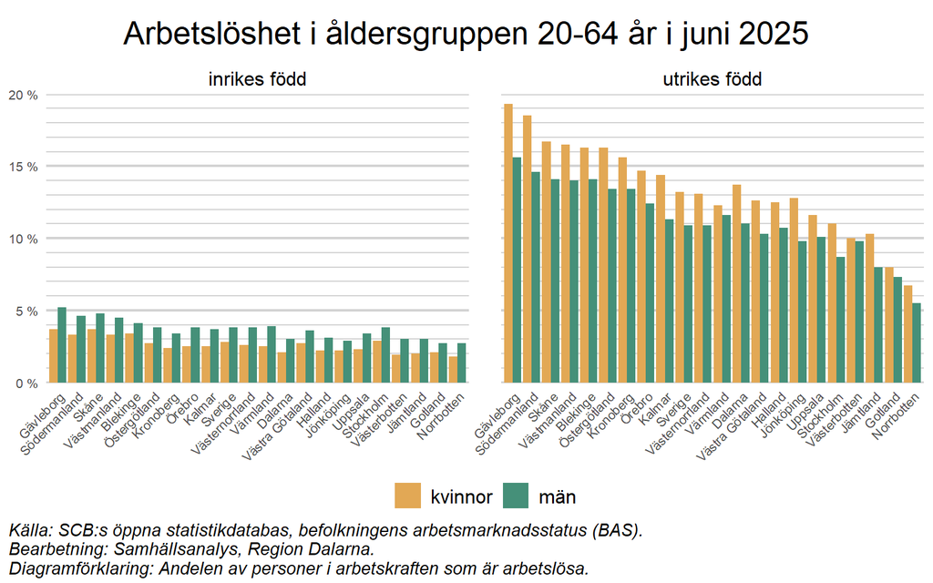

I diagrammet ovan framgår också att det finns avsevärda skillnader mellan länen. Norrbotten har den lägsta arbetslösheten för såväl utrikes födda män som kvinnor med 5,5 respektive 6,7 procent.

Högst arbetslöshet för såväl utrikes födda män som kvinnor har Gävleborg med 15,6 procent för män och 19,3 procent för kvinnor. Dalarna ligger något över riksgenomsnittet, men uppvisar inte extrema arbetslöshetssiffror åt något håll.

Även bland länets kommuner är variationen i arbetslöshet stor. För inrikes födda var arbetslösheten något högre för män än för kvinnor, men generellt låg i samtliga Dalarnas kommuner. Högst arbetslöshet för inrikes födda män i Dalarna finns i Hedemora, men skillnaden gentemot genomsnittet i länet är relativt liten.

Bland inrikes födda kvinnor finns den högsta arbetslösheten i Smedjebacken.

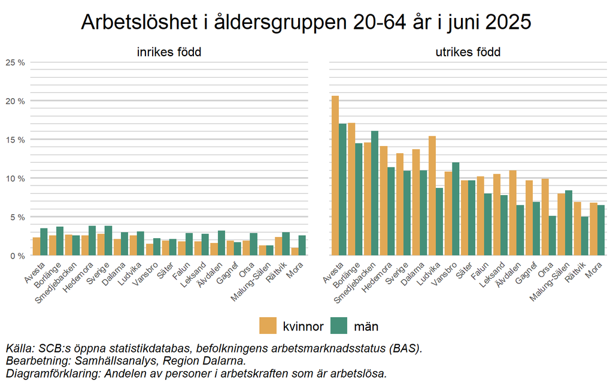

Bland utrikes födda är arbetslösheten avsevärt mycket högre för både kvinnor och män, och i de flesta kommuner är arbetslösheten högre för utrikes födda kvinnor än för utrikes födda män. Genomsnittet i Dalarnas län ligger på 13,7 procent bland utrikes födda kvinnor och 11 procent bland utrikes födda män. Arbetslösheten är dessutom klart högre för utrikes födda jämfört med inrikes födda, oavsett kön.

Arbetslösheten för utrikes födda kvinnor i Dalarna är högst i Avesta, där arbetslösheten i gruppen är hela 20,6 procent. För inrikes födda kvinnor är motsvarande siffra blott 2,3 procent. Även för utrikes födda män i Dalarna är arbetslösheten högst i Avesta, med en arbetslöshet i gruppen på 17 procent. För inrikes födda män är motsvarande siffra 3,5 procent.

Lägst arbetslöshet bland utrikes födda kvinnor har Mora med 6,8 procent, medan arbetslösheten bland utrikes födda män är lägst i Rättvik med 5 procent. Den grupp av utrikes födda som ligger närmast nivåerna för inrikes födda är födda i Norden. Andelen arbetslösa är väsentligt högre bland personer födda i Asien och Afrika, vilka är två världsdelar från vilka flyktinginvandringen varit stor under det senaste decenniet.

De skillnader i arbetslöshet som observeras kan sannolikt förklaras av skillnader i mängden personer, när i tid som de invandrat till olika kommuner och med vilken utbildningsnivå. En ytterligare dimension som påverkar arbetslösheten är den demografiska utvecklingen med en allt äldre inrikes född befolkning. Arbetskraftsreserven består i allt större grad av utrikes födda, och den åldrande inrikes födda befolkningen leder till pensionsavgångar som i sin tur öppnar för utrikes föddas inträde på arbetsmarknaden. Ju bättre rustade de utrikes födda är, desto enklare sker etableringen på arbetsmarknaden. Den allt äldre befolkningen leder även till ökade behov inom bl a vård och omsorg, en bransch där många utrikes födda arbetar idag.

För att få en uppfattning om skillnader i arbetslöshet mellan inrikes och utrikes födda, räcker det dock inte med att enbart studera situationen idag, utan även förändringen över tid är av vikt.

För inrikes födda har arbetslösheten minskat något sedan coronapandemin (2020-2021), men varit relativt stabil på senare år. I juni 2025 var arbetslösheten bland inrikes födda 2,5 procent i Dalarna. Bland utrikes födda har arbetslösheten minskat stadigt och markant sedan en topp under pandemin (den var 22,5 procent i juni 2020), men är som sagt klart högre än bland inrikes födda (12,3 procent i juni 2025).

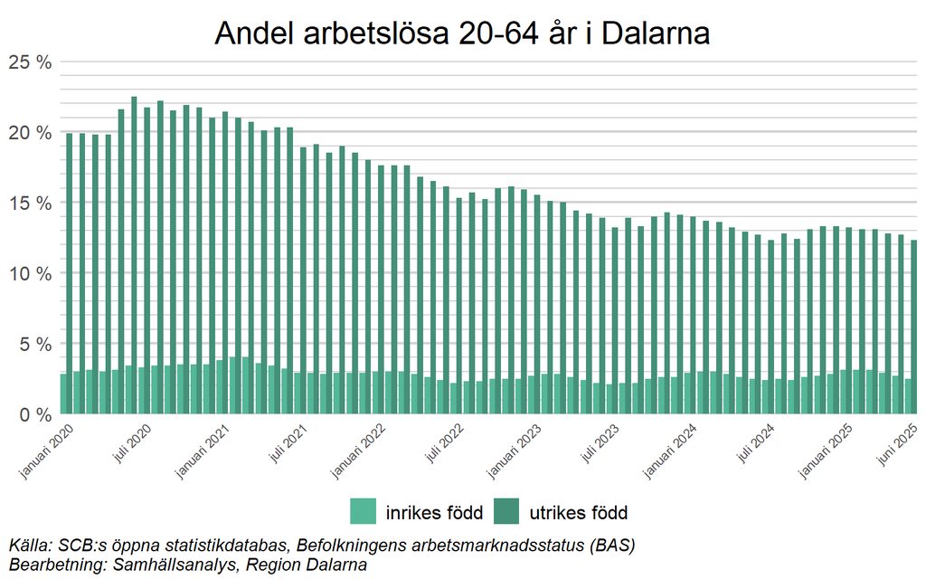

Att en större andel utrikes födda arbetar idag, jämfört med för ett par år sedan, är mycket viktigt för integrationen, då möjligheten att försörja sig själv och skapa nya sociala sammanhang ses som en av de viktigaste faktorerna för att integreras i samhället ([Jönköpings universitet](https://ju.se/forskning/langlasning/arkiv/2022-03-04-engagemang-kontakter-och-sprakkunskaper-ger-snabbare-integration-pa-arbetsmarknaden.html)).

Totalt var 2 748 inrikes födda personer och 2 521 utrikes födda personer i åldersgruppen 20-64 år arbetslösa i Dalarna i juni 2025.

Hur långt ifrån arbetsmarknaden som en individ befinner sig beror delvis på hur länge personen har varit utan anställning. En person som har varit arbetslös länge har ofta svårare att ta sig tillbaka in på arbetsmarknaden. Bland arbetslösa inrikes födda i åldersgruppen 20-64 år har ungefär 29 procent varit arbetslösa länge (minst 24 månader) och får anses stå väldigt långt från arbetsmarknaden. Sammanlagt har ungefär 44 procent av de inrikes födda i åldersgruppen som är arbetslösa varit det i minst 12 månader. Istället är det de som har varit arbetslösa under en relativt kort period (<6 månader) som är den största gruppen (ca 39 procent av alla inrikes födda arbetslösa).

Bland utrikes födda är bilden delvis annorlunda. Här är den största gruppen arbetslösa de som varit det i minst 24 månader, totalt 42 procent av de arbetslösa utrikes födda tillhör den gruppen. Sammanlagt har ungefär 63 procent av de arbetslösa utrikes födda varit det i minst 12 månader.

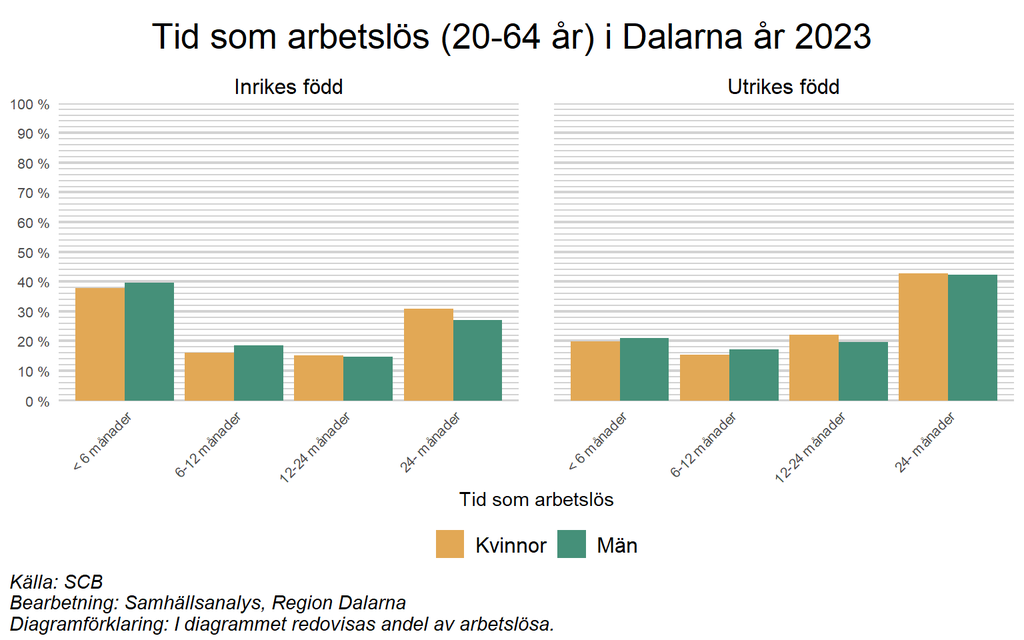

Fördelningen är relativt jämn mellan kvinnor och män. Bland inrikes födda har en något större andel kvinnor än män varit arbetslösa länge (mer än 24 månader), medan en något större andel män än kvinnor varit arbetslösa under en kort period. För utrikes födda har ungefär lika stor andel kvinnor som män varit arbetslösa i minst 24 månader.

Sysselsättningsgraden, det vill säga i vilken utsträckning människor i arbetsför ålder (20-64 år) arbetar, är ett annat sätt att titta på arbetsmarknaden. Den mäter andelen av hela befolkningen som har ett arbete. Sysselsättningsgraden skiljer sig inte märkbart åt mellan könen bland inrikes födda som ses i det vänstra diagrammet nedan. Sverige ligger långt fram i en internationell jämförelse när det gäller att ge kvinnor och män likvärdiga möjligheter att yrkesarbeta, och det återspeglas i sysselsättningsgraden som för båda könen är ungefär lika hög, 85,2 procent för kvinnor och 84,2 procent för män. Variationen i sysselsättningsgrad mellan länen är därför också relativt liten.

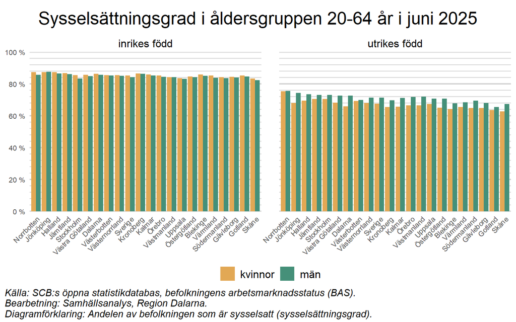

Däremot skiljer sig sysselsättningsgraden åt mellan inrikes och utrikes födda. För utrikes födda (det högra diagrammet ovan) är sysselsättningsgraden lägre än sysselsättningsgraden för inrikes födda i samtliga svenska län. Det finns även skillnader mellan kvinnor och män.

Utrikes födda män har en högre sysselsättningsgrad än utrikes födda kvinnor i samtliga län. I Dalarna var sysselsättningsgraden bland utrikes födda män 72,5 procent, vilket är cirka 7 procentenheter fler än för utrikes födda kvinnor i Dalarna.

Sysselsättningsgraden i åldersgruppen 20-64 år har ökat för såväl inrikes som utrikes födda i Dalarna sedan det tidiga 1990-talet. År 1993 var sysselsättningsgraden för inrikes födda kvinnor i Dalarna 72,6 procent, vilket var något högre än för männen, 71,4 procent. Att de inrikes födda kvinnornas sysselsättningsgrad var högre än männens beror sannolikt på 90-talskrisen, när branscher med stor dominans av män bland de anställda (industri exempelvis) drabbades hårt.

För utrikes födda var sysselsättningsgraden ungefär lika stor för kvinnor och män, men klart lägre än för inrikes födda (50 procent för kvinnor och 50,6 procent för män). Den här utvecklingen innebär att skillnaden i sysselsättningsgrad mellan utrikes och inrikes födda män har minskat de senaste 30 åren. Sedan mitten på 2010-talet har utvecklingen varit särskilt stark för utrikes födda män. Däremot kvarstår nästan hela den relativa skillnaden mellan utrikes och inrikes födda kvinnor över tid.

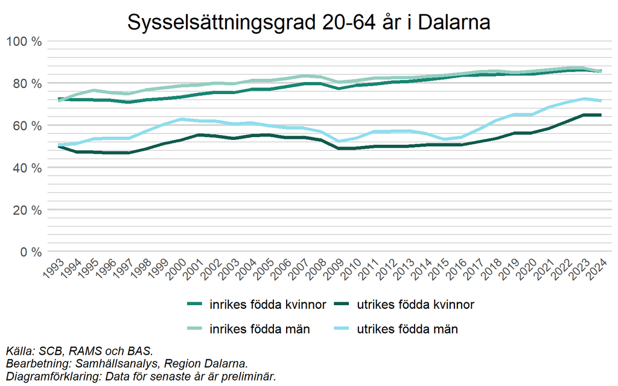

År 2024 hade sysselsättningsgraden ökat till 85,6 procent för inrikes födda kvinnor och 85,3 procent för inrikes födda män. Inrikes födda kvinnor har således fortfarande något högre sysselsättningsgrad än inrikes födda män. Även för utrikes födda har sysselsättningsgraden ökat tydligt för båda könen, men med 71,7 procent har de utrikes födda männen idag en klart högre sysselsättningsgrad än 64,7 procent för de utrikes födda kvinnorna.

En jämförelse av sysselsättningsgraden i respektive kommun i Dalarna ger en liknande bild som syns i den länsvisa jämförelsen ovan. Gruppen inrikes födda har en högre sysselsättningsgrad i samtliga kommuner i Dalarna jämfört med utrikes födda. Även här är sysselsättningsgraden för inrikes födda kvinnor och män ungefär lika hög. För utrikes födda är det däremot stora skillnader mellan kvinnor och män, också mellan olika kommuner. I linje med den nationella bilden är sysselsättningsgraden högre för gruppen utrikes födda män i jämförelse med utrikes födda kvinnor i de flesta kommuner. Sysselsättningsgraden för utrikes födda män skiljer sig dock åt mellan kommuner där den högsta sysselsättningsgraden finns i Ludvika (77,6 procent) och den lägsta i Älvdalen (64,7 procent).

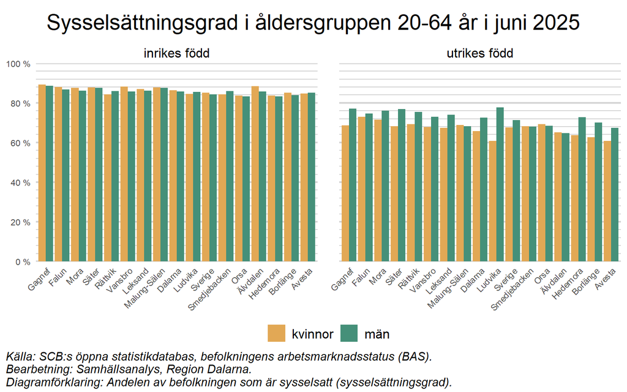

Falun har den högsta sysselsättningsgraden för gruppen utrikes födda kvinnor i Dalarna, 72,9 procent, och ligger klart över genomsnittet för länet. Samtidigt är sysselsättningsgraden i Ludvika kommun bland utrikes födda kvinnor bara 60,7 procent.

En del av skillnaden i utrikes föddas sysselsättningsgrad mellan kommunerna kan sannolikt förklaras av skillnader i antalet personer som invandrade under åren runt 2015 då invandringen till Sverige var mycket stor, vilket påverkar individers tid att etablera sig på arbetsmarknaden. Exempelvis var Avesta, Ludvika och Hedemora de tre kommuner som hade högst invandring i förhållande till folkmängd under 2015-2017. Detta förefaller i första hand gälla för utrikes födda kvinnor, då både Hedemora och Ludvika har relativt hög sysselsättningsgrad för utrikes födda män, medan den är klart lägre för utrikes födda kvinnor. I Ludvika är skillnaden mellan könen i sysselsättningsgrad ungefär 17 procentenheter, vilket är den största skillnaden i länet.

När andelen sysselsatta redovisas per utbildningsnivå är det tydligt att individer med förgymnasial utbildning i lägre utsträckning är förvärvsarbetande (se diagram nedan), vilket även gäller gruppen utrikes födda. För personer med förgymnasial utbildning är sysselsättningsgraden bland utrikes födda i Dalarna blott 52,7 procent medan den är 67,1 procent för inrikes födda med motsvarande utbildning, en skillnad på 14,4 procentenheter mellan inrikes och utrikes födda. I avsnittet om utbildning noteras att bland utrikes födda är det män och kvinnor med förgymnasial utbildning som bidrar till den låga sysselsättningsgraden.

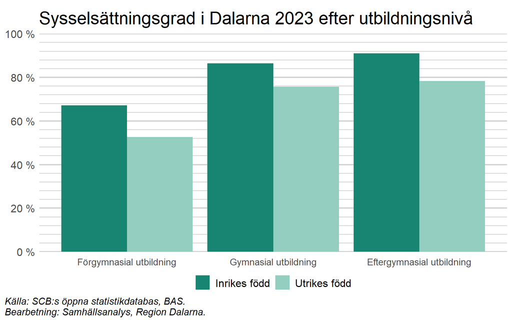

För såväl utrikes som inrikes födda ökar sysselsättningsgraden tydligt om personerna istället har en gymnasial utbildning. Då ökar sysselsättningsgraden bland utrikes födda till 75,8 procent medan den för inrikes födda är 86,4 procent. Det ger en skillnad på 10,6 procentenheter mellan inrikes och utrikes födda.

Bland personer med eftergymnasial utbildning är sysselsättningsgraden för utrikes födda 78,4 procent, vilket bara är något högre än för gymnasialt utbildade i samma grupp. För inrikes födda med en eftergymnasial utbildning är sysselsättningsgraden hela 91 procent, vilket är 12,6 högre än för utrikes födda med samma utbildningsnivå.

Skillnaden i sysselsättningsgrad mellan utrikes och inrikes födda är således som störst bland de med lägst utbildningsnivå (förgymnasial), men sjunker tydligt för personer med gymnasial utbildning (från 14,4 procentenheter till 10,6 procentenheter). För de personer som har högst utbildning (eftergymnasial) ökar skillnaden återigen i sysselsättningsgrad mellan inrikes och utrikes födda, till 12,6 procentenheter.

För dem med lägst utbildningsnivå (förgymnasialt utbildade) är relativt få etablerade på arbetsmarknaden. I den gruppen arbetar bara ungefär 11 procent av de utrikesfödda kvinnor, och cirka 29 procent av de utrikesfödda männen, inom 2 år efter att de kommit till Sverige. Andelen etablerade ökar sedan med vistelsetiden, men är på klart lägre nivåer än för grupper med högre utbildningsnivåer. Även bland inrikes födda är det en klart lägre andel med förgymnasial utbildning som är etablerade på arbetsmarknaden.

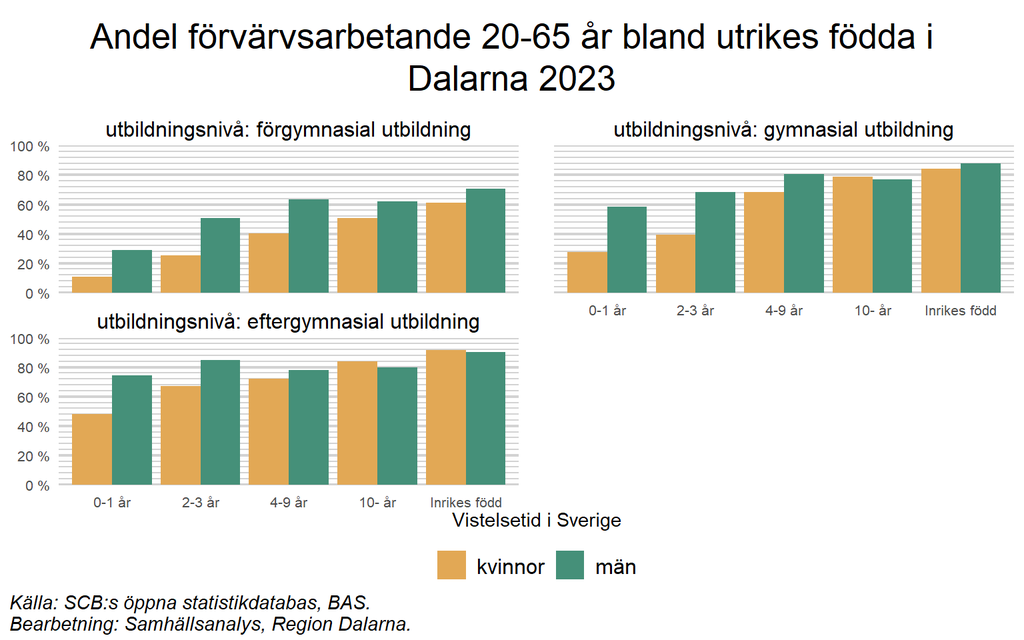

En bidragande orsak till att utrikes födda personer med låg utbildning har svårare att etablera sig på arbetsmarknaden kan vara att det finns få enkla jobb på den svenska arbetsmarknaden som inte kräver längre utbildning. För att möjliggöra att fler av de utrikes födda som flyttar till Dalarna ska arbeta, är det av största vikt att så många som möjligt tillgodogör sig en utbildning som efterfrågas av arbetsmarknaden.

Det finns flera tänkbara anledningar till att utrikes födda i genomsnitt presterar sämre på arbetsmarknaden, även när hänsyn tas till skillnader i utbildningsnivå. Några tänkbara förklaringar kan exempelvis vara lägre kunskaper om landet, språket och kulturen. För de som flyttat till Sverige av flyktingskäl kan traumatiska upplevelser också inverka. Det finns emellertid rapporter som visar att diskriminering av personer med utländskt ursprung förekommer på arbetsmarknaden [(Länsstyrelsen Stockholm, 2018)](https://www.diva-portal.org/smash/get/diva2:1273400/FULLTEXT01.pdf)[^13]. Utrikes födda män förefaller vara mer utsatta inom yrken där det finns många inrikes födda [(Bursell, M. och Bygren, M., 2023)](https://www.ifau.se/globalassets/pdf/se/2023/2023-10-etnisk-yrkessegregering-pa-arbetsmarknaden--har-diskriminering-nagon-betydelse.pdf)[^14].

Om fokus enbart är på kopplingen mellan vistelsetid och sysselsättningsgrad, blir det tydligt att vistelsetiden är en viktig faktor för att skapa integration i samhället (se diagrammet nedan). De som vistats längre tid i Sverige har en högre förvärvsfrekvens. Variabeln vistelsetid fungerar som en indikator på en rad andra faktorer som påverkar möjligheterna till att få ett arbete. Ökad tid i landet ger möjlighet för en nyanländ person att lära sig svenska, validera och komplettera utbildningar, lära sig hur den svenska arbetsmarknaden fungerar samt knyta kontakter för att öka chansen till att få en sysselsättning och inkomst. Enligt detta resonemang förväntas ett initialt sysselsättningsgap mellan inrikes födda och nyanlända, som minskar succesivt när vistelsetiden i landet blir längre.

Som diskuterats tidigare är sysselsättningsgraden lägre bland utrikes födda generellt, och för invandrade kvinnor tar det betydligt längre tid än för invandrade män att etablera sig på arbetsmarknaden. Skillnaderna som finns mellan arbetslöshet och sysselsättningsgrad indikerar att en större andel utrikes födda kvinnor än män i arbetsför ålder inte står till arbetsmarknadens förfogande. För utrikesfödda kvinnor som befunnit sig i Sverige i upp till 2 år (0-1 år i diagrammet nedan) är det bara ungefär 31 procent i arbetsför ålder (20-65 år) som arbetar. För motsvarande grupp av män är ungefär 62 procent i arbete inom 2 år. Över tid tenderar ändå sysselsättningsgraden att öka avsevärt och efter mer än tio år i Sverige är det över 70 procent av invandrade, såväl män som kvinnor, som arbetar.

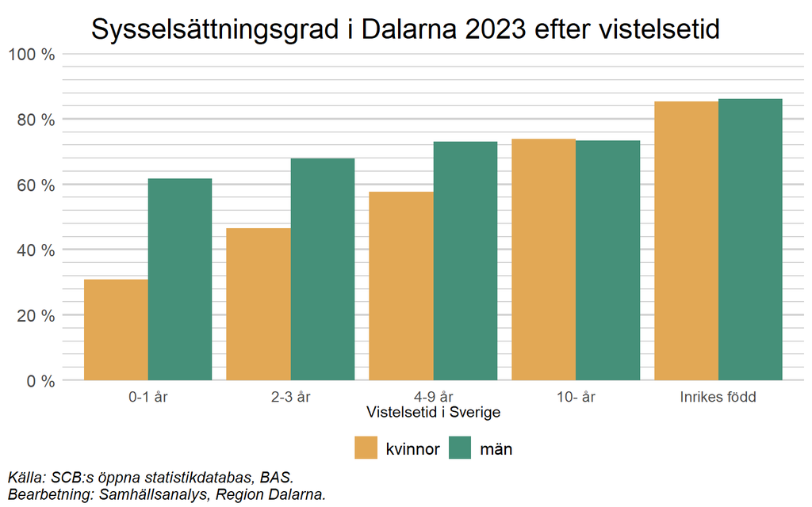

Bland utrikes födda har män en högre sysselsättningsgrad än kvinnor bland dem med vistelsetid kortare än 10 år, innan kvinnorna får en något högre sysselsättningsgrad än männen. Bland inrikes födda är sysselsättningsgraden något högre för män än för kvinnor.

Skillnaderna mellan könen minskar som synes med vistelsetiden i Sverige. [Emma Neuman (2015)](https://www.diva-portal.org/smash/get/diva2:822705/FULLTEXT01.pdf)[^15] har undersökt hur kulturella normer bidrar till arbetsmarknadsutfall mellan utrikes födda kvinnor och män i Sverige. Kartläggningen visade att de som invandrat från länder där arbetsdeltagandet för kvinnor var lägre än män, också hade stora skillnader i andelen sysselsatta per kön på den svenska arbetsmarknaden. Efter en längre vistelsetid i Sverige, minskade gapet och skillnaden i sysselsättningsgrad mellan könen närmar sig nivån för inrikes födda. Slutsatsen som drogs var att den kulturella inverkan som ansågs finnas avtar med tiden. Mönstret med en stor skillnad i sysselsättningsgrad mellan kön för utrikes födda med en kort vistelsetid går att se även i Dalarna. Skillnaden mellan könen minskar ju längre vistelsetiden i landet blir, och har helt försvunnit för de som bott i Sverige i 10 år eller mer.

Skillnaden mellan utrikes födda kvinnor och utrikes födda män kan även förklaras med att kvinnor som invandrat från ett utomeuropeiskt land i majoriteten av fallen har gjort det som anhörig, antingen till en person med svenskt medborgarskap eller till en person med permanent uppehållstillstånd. Att vara anhörig till arbetskraftsinvandrare är även vanligt förekommande. Givet dessa skäl för invandring är det vanligt att kvinnor invandrar med små barn eller har ett högt barnafödande de första åren i landet. Det har visat sig att kvinnorna sedan tar ett betydligt större omsorgsansvar för barn än barnens fäder, vilket bidrar till att deras inträde på arbetsmarknaden sker betydligt senare än för män i motsvarande situation. Exempelvis är användningen av föräldrapenning mycket ojämställd bland nyligen invandrade föräldrar (se [Expertgruppen för studier i offentlig ekonomi (2021)](https://eso.expertgrupp.se/wp-content/uploads/2020/03/ESO-2021_7_forsorjning-med-fordrojning_webb.pdf)[^16] och [Jämställdhetsmyndigheten (2022)](https://jamstalldhetsmyndigheten.se/media/s5wdbimq/rapport-sta-rkta-mo-jligheter-genom-samverkan.pdf)[^17]).

Att vara anhöriginvandrare sätter också kvinnan i fråga i en särskild beroendeställning till sin respektive anhörige i jämförelse med om hon invandrat eller flytt på egna premisser. Detta i kombination med ofta låg utbildning och brist på arbetslivserfarenhet från hemlandet blir också hinder för att delta i integrationsinsatser, utbildning och arbetssökande (se exempelvis [Expertgruppen för studier i offentlig ekonomi (2021)](https://eso.expertgrupp.se/wp-content/uploads/2020/03/ESO-2021_7_forsorjning-med-fordrojning_webb.pdf)[^18] och [Regeringen (2023)](https://www.regeringen.se/contentassets/aaae962745b74fa4abc01f7926bb5adc/sou-2023_24_pdf-a_webb.pdf)[^19]).

Hur snabbt en nyligen invandrad person etablerar sig på arbetsmarknaden har förändrats avsevärt över tid, vilket åskådliggörs i diagrammet nedan. Från början av 2000-talet fram till mitten av 2010-talet låg etableringstiden relativt stabil, där ungefär 20 procent av de 20-64 åringar som varit i Sverige i upp till 2 år (0-1 år i figuren nedan) förvärvsarbetade och ungefär 50-60 procent av de 20-64 åringar som varit i Sverige mellan 4 och 10 år (4-9 år i figuren nedan) förvärvsarbetade. Efter den stora flyktinginvandringen i mitten av 2010-talet verkar dock någonting ha hänt och framförallt personer med kort vistelsetid (upp till 2 år) kommer i arbete betydligt snabbare. Mellan 2015 och 2023 ökade andelen förvärvsarbetande av de 20-64 åringar som varit i Sverige i upp till 2 år (0-1 år i figuren nedan) från ungefär 16 procent till cirka 46 procent, en remarkabel förbättring. Under samma tidsperiod har även arbetslösheten för gruppen utrikes födda minskat betydligt, vilket illustrerats i ett tidigare diagram. Värt att notera är att det i diagrammet nedan är andelen förvärvsarbetande i åldersgruppen 20-64 år som redovisas mellan 1997 och 2021, medan det är andelen förvärvsarbetande i åldergruppen 20-65 år som redovisas åren därefter.

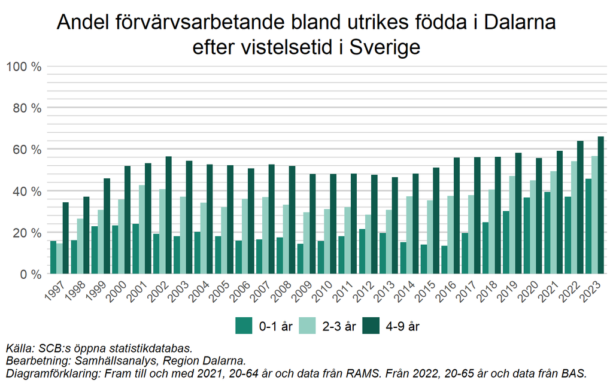

Regeringen har under år 2023 satt fokus på insatser som ska få utrikes födda kvinnor i arbete snabbare. Bland annat har länsstyrelserna ett regionalt uppdrag med detta som mål.

## 3.2 UVAS

Avslutningsvis är det även viktigt att titta på de unga individer som varken arbetar eller studerar (UVAS). För mer information om denna grupp, se [MUCF](https://www.mucf.se/uppdrag/unga-som-varken-arbetar-eller-studerar).

Bland personer mellan 16 och 19 år (det vänstra diagrammet nedan) är andelen som varken arbetar eller studerar högre för män än för kvinnor, oavsett om personen är inrikes eller utrikes född. Andelen är som högst för personer som vistats i Sverige en kort tid, men sjunker med vistelsetid. För utrikes födda kvinnor sjunker andelen som varken arbetar eller studerar bland 16-19-åringar från 15 procent för de som varit i Sverige i max 2 år till 6 procent för de som varit i landet i minst 10 år. Motsvarande andel för inrikes födda kvinnor är 7 procent.

För utrikes födda män sjunker motsvarande andel bland 16-19-åringar från cirka 27 procent för de som varit i Sverige i max 2 år till ungefär 13 procent för de som varit i landet i minst 10 år. Noterbart är dock att andelen är högre för män som varit i Sverige i mer än 10 år, än för de som varit i landet mellan 2 och 10 år. Bland inrikes födda män mellan 16 och 19 år, som varken arbetar eller studerar, är andelen 10 procent.

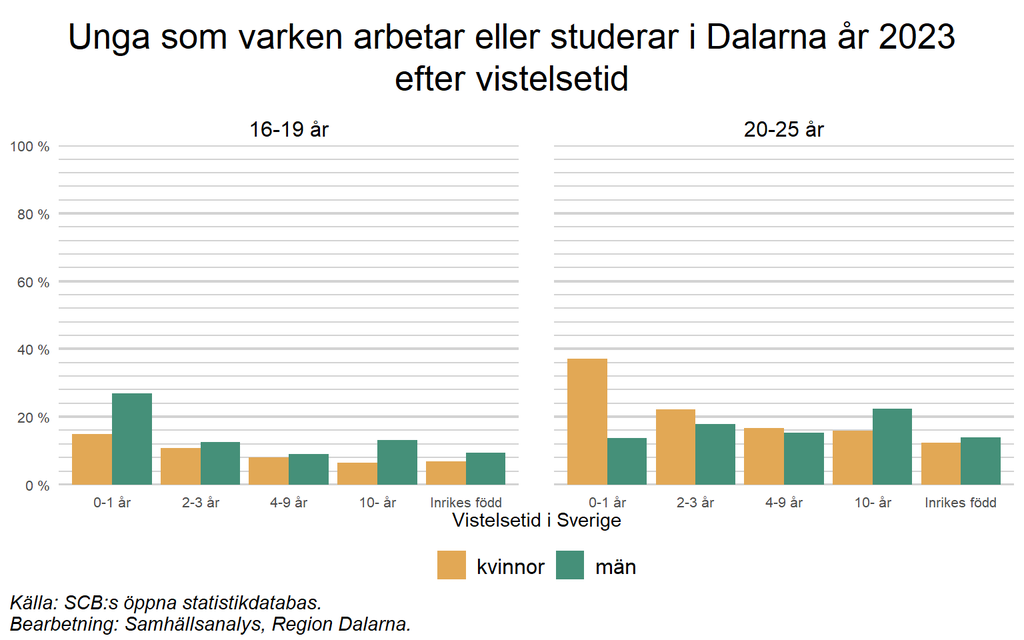

Om de unga mellan 20 och 25 år som varken arbetar eller studerar i stället undersöks framträder en delvis annorlunda bild (se det högra diagrammet ovan). Bland kvinnor är andelen högre i denna åldersgrupp än den var bland 16-19-åringar, oavsett om personen är inrikes eller utrikes född. För utrikes födda kvinnor sjunker andelen som varken arbetar eller studerar bland 20-25-åringar från 37 procent för de som varit i Sverige i max 2 år till 16 procent för de som varit i landet i minst 10 år. Motsvarande andel för inrikes födda kvinnor är 12 procent.

För utrikes födda män är trenden omvänd, där andelen som varken arbetar eller studerar bland 20-25-åringar istället ökar med vistelsetiden, från ca 14 procent för de som varit i Sverige i max 2 år till ungefär 22 procent för de som varit i landet i minst 10 år. Motsvarande andel bland inrikes födda män i samma ålder är 14 procent.

Utrikes födda män mellan 20 och 25 år förefaller således hamna i någon form av sysselsättning snabbare än män i åldersgruppen 16-19 år, men därefter ökar andelen som varken arbetar eller studerar bland 20-25-åringarna, medan den minskar för de mellan 16-19 år. Bland utrikes födda kvinnor är andelen som varken arbetar eller studerar högre bland 20-25-åringar än bland 16-19-åringar, oavsett vistelsetid, ett mönster som även gäller för inrikes födda kvinnor och män.

Andelen utrikes födda som varken arbetar eller studerar har förändrats relativt mycket över tid. I slutet på 1990-talet varken arbetade eller studerade runt 60 procent av de utrikes födda mellan 16 och 19 år som varit i Sverige i max 2 år, att jämföra med 22 procent idag. Den största minskningen skedde i början på 2000-talet och därefter har andelen varierat en del över tid. En liknande trend går att utläsa bland utrikes födda 16-19 åringar som varit i landet längre, men bland dessa är andelen som varken arbetar eller studerar tydligt lägre.

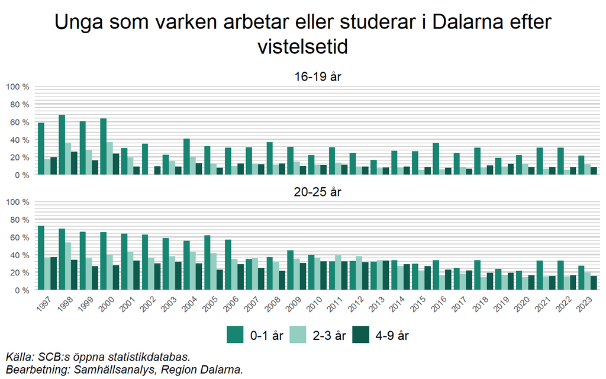

Även bland utrikes födda mellan 20 och 25 år har motsvarande andel förändrats mycket över tid. I slutet på 1990-talet varken arbetade eller studerade runt 70 procent av de utrikes födda mellan 20 och 25 år som varit i Sverige i max 2 år, att jämföra med 28 procent idag. En stor del av minskningen skedde i mitten på 2000-talet och därefter har andelen gått såväl upp som ner. En liknande utveckling syns även bland utrikes födda 20-25-åringar som varit i landet längre. En trolig förklaring till de höga nivåerna under 1990-talet var den ekonomiska kris som berörs i det föregående avsnittet.

Språk och utbildning är avgörande för etablering på arbetsmarknaden. En hög asylinvandring gör att samhället behöver resurssätta för att möta behoven av grundläggande språkutbildning som i sin tur ger möjlighet att tillgodogöra sig utbildning. Det är tydligt att det är en process som kräver tid, men de flesta områden utvecklas också positivt över tid. Under senare år har vistelsetidens påverkan på integrationen förkortats, vilket kan vara ett tecken på att invandringen de senaste åren är av annan karaktär än under åren efter 2015.